# Representatividad, ajuste y estimación de voto con datos de encuesta

# 3. Creación de una tabla con las estimaciones de la muestra y sus diferencias con los datos poblacionales

```r
#Tabla con las estimaciones de la muestra

tabla_muestra <- data %>%
  tab_cells(sexo, edad, estudios, sitlab) %>%
  tab_stat_cpct() %>%
  tab_pivot()

colnames(tabla_muestra) <- c("variable_valor", "muestra")

#Tabla de los datos de la encuesta con los datos poblacionales y cálculo de las diferencias
tabla_muestra_pobla <- left_join(tabla_muestra, datos_poblacionales, by = "variable_valor")

tabla_muestra_pobla <- tabla_muestra_pobla %>%
  mutate(dif = round(muestra - pobla, 1)) %>%
  filter(!is.na(dif))
```

# 4. Análisis de las desviaciones de la muestra

El **MAE** (mean sbsolute error) es una medida resumen empleada para evaluar el error total al comparar las distribuciones de dos variables categóricas.

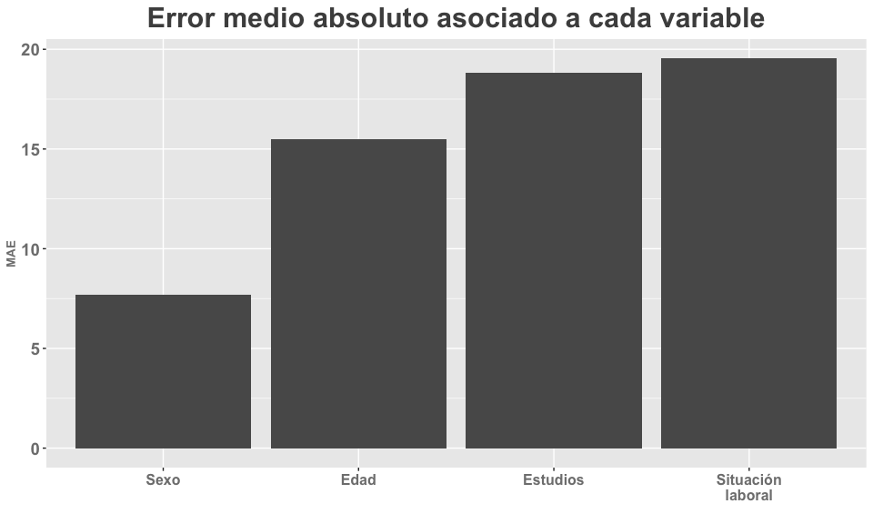

```r
##Gráfico del MAE: error medio absoluto

tabla_muestra_pobla %>%
  mutate(dif_abs = abs(dif)) %>%
  group_by(variable) %>%
  summarise(mae = mean(dif_abs)) %>%
  ggplot(aes(x = reorder(variable, mae), y = mae)) +
  geom_col()+
  labs(title = "Error medio absoluto asociado a cada variable",
       x ="", y="MAE")+
  scale_x_discrete(labels = c("Sexo","Edad","Estudios","Situación\nlaboral"))+
  theme(plot.title = element_text(hjust = 0.5, size = 23,color = "grey30", face = "bold"),
        plot.subtitle = element_text(hjust = 0.5, color = "grey30",face = "bold", size = 17),
        axis.title.x = element_text(hjust = 0.5, size = 10,
                                    color = "grey50",face = "bold"),
        axis.title.y = element_text( size= 10,face = "bold", color = "grey50"),
        axis.text.x = element_text(size = 12,face = "bold", color = "grey50"),
        legend.position = c(0.8, 0.2), legend.text = element_text(color = "white"),
        axis.text.y = element_text(size = 14,face = "bold", color = "grey50"),
        plot.caption = element_text(size = 11, hjust=0, color = "grey30"))
```

```r
tabla_muestra_pobla %>%
  filter( variable %in% c("sexo","edad","estudios","sitlab"))%>%
  select(variable, valor, muestra, pobla, dif)%>%
  kableExtra::kable()%>%
  kable_styling(bootstrap_options = "striped", full_width = F)
```

| variable | valor | muestra | pobla | dif |
| --- | --- | --- | --- | --- |
| sexo | Hombre | 57.377049 | 49.64 | 7.7 |
| sexo | Mujer | 42.622951 | 50.35 | -7.7 |
| edad | 18-29 | 38.797814 | 20.67 | 18.1 |
| edad | 30-44 | 37.704918 | 24.80 | 12.9 |
| edad | 45-64 | 21.311475 | 33.45 | -12.1 |
| edad | 65 y + | 2.185792 | 21.06 | -18.9 |
| estudios | Sin estudios | 1.639344 | 22.42 | -20.8 |
| estudios | Educación primaria | 12.021858 | 17.77 | -5.7 |
| estudios | Educación superior (Licenciatura, grado, máster…) | 41.530055 | 11.52 | 30.0 |
| sitlab | Trabaja | 68.852459 | 41.02 | 27.8 |
| sitlab | Parado/a | 16.939891 | 15.45 | 1.5 |
| sitlab | Inactivo/a | 14.207650 | 43.52 | -29.3 |

# 5. Cálculo de pesos con las variables sociodemográficas

## 5.1. Preparación de los totales poblacionales

```r
# Calibración sociodemográfica con sexo, edad, estudios y ocupación
# Total poblacional del censo electoral es de 10870 (SIMA)

vars_socdem <- c("sexo", "edad", "estudios", "sitlab")

pobla_socdem <- datos_poblacionales %>%
  mutate(total_pobla = round(pobla/100*10870, 0)) %>%
  filter(variable %in% vars_socdem) %>%
  filter(valor_orden != 1)

totales_pobla <- pobla_socdem$total_pobla
names(totales_pobla) <- paste0(pobla_socdem$variable, pobla_socdem$valor)
totales_pobla <- c("(Intercept)" =  10870, totales_pobla)

kableExtra::kable(totales_pobla, col.names = c("Totales poblacionales"))%>%
      kable_styling(bootstrap_options = "striped", full_width = F)
```

|  | Totales poblacionales |
| --- | --- |
| (Intercept) | 10870 |
| sexoMujer | 5473 |
| edad30-44 | 2696 |
| edad45-64 | 3636 |
| edad65 y + | 2289 |
| estudiosEducación primaria | 1932 |
| estudiosEducación Secundaria Obligatoria | 3666 |
| estudiosEducación pos Secundaria (Bachillerato, FP) | 1579 |
| estudiosEducación superior (Licenciatura, grado, máster…) | 1252 |
| sitlabParado/a | 1679 |
| sitlabInactivo/a | 4731 |

## 5.2. Preparación de los datos de la encuesta

```r
# Elevar el peso al total poblacional
data <- data %>%
  mutate(peso_pobla = 10870/nrow(.))
```

## 5.3. Diseño de encuesta y calibración

```r
# Establecer diseño de la encuesta
# Proceder con la calibración

svy_des <- svydesign(ids = ~ 0, weights = ~ peso_pobla, data = data)

calib_socdem <- calibrate(design = svy_des,
                          formula = ~ sexo + edad + estudios + sitlab,
                          population = totales_pobla,
                          force = T,
                          calfun = "logit",
                          bounds=c(0, 5))
```

## 5.4. Evaluación de la calibración

```r
# Extracción de la ponderación y combinación con encuesta
# Comprobación de mínimos y máximos del peso
# Comprobación de coincidencia con totales poblacionales

# Estadísticos descriptivos del peso
peso_calib_socdem <- weights(calib_socdem)
data$peso_calib_socdem <- peso_calib_socdem

sjmisc::descr(data$peso_calib_socdem) %>%
  kableExtra::kable()%>%
  kable_styling(bootstrap_options = "striped", full_width = F)
```

| var | type | label | n | NA.prc | mean | sd | se | md | trimmed | range | iqr | skew |
| --- | --- | --- | --- | --- | --- | --- | --- | --- | --- | --- | --- | --- |
| dd | numeric | dd | 183 | 0 | 57.7049 | 83.83561 | 6.197306 | 4.753658 | 40.02339 | 296.89 (0.1-296.99) | 98.19359 | 1.558785 |

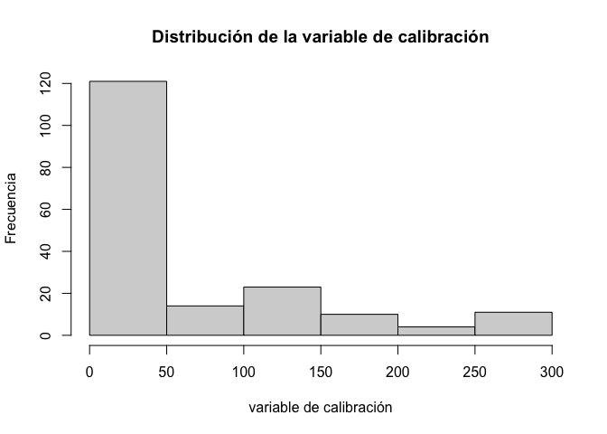

```r
hist(data$peso_calib_socdem,
     main = "Distribución de la variable de calibración",
     xlab = "variable de calibración",
     ylab = "Frecuencia")
```

```r
# Comprobación de los totales poblacionales y de la muestra ponderada para observar si coinciden
tabla <- data %>%
  tab_weight(peso_calib_socdem) %>%
  tab_cells(sexo, edad, estudios, sitlab) %>%
  tab_stat_cpct(total_statistic = "w_cpct") %>%
  tab_pivot()

colnames(tabla) <- c("variable_valor", "calibrado")

tabla_checks <- left_join(tabla, datos_poblacionales, by = "variable_valor") %>%
  mutate(dif = round(calibrado - pobla, 1))

sum(tabla_checks$dif, na.rm = T)
```

[1] -7.2

## 5.5. Finalizar peso

```r
# Escalar para que tenga media 1

data <- data %>%
  mutate(peso_calib_socdem = peso_calib_socdem/mean(peso_calib_socdem))
sjmisc::descr(data$peso_calib_socdem) %>%
      kableExtra::kable()%>%
  kable_styling(bootstrap_options = "striped", full_width = F)
```

| var | type | label | n | NA.prc | mean | sd | se | md | trimmed | range | iqr | skew |
| --- | --- | --- | --- | --- | --- | --- | --- | --- | --- | --- | --- | --- |
| dd | numeric | dd | 183 | 0 | 1 | 1.452833 | 0.1073965 | 0.0823787 | 0.6935873 | 5.14 (0-5.15) | 1.701651 | 1.558785 |

# 6. Filtro de participación

```r
#Filtro de participación

data$prob.voto <- 0
data$prob.voto[data$participacion_electoral == "Sí, con toda seguridad"] <- 1
data$prob.voto[data$participacion_electoral != "Sí, con toda seguridad"] <- 0
unweighted <-  wpct(data$prob.voto)
weighted  <-  wpct(data$prob.voto, data$peso_calib_socdem)
tab  <- data.frame(unweighted, weighted)
rownames(tab) <- c("No votará", "Votará")
data <- data[data$prob.voto == 1, ]
ktab_participacion <- kable(tab, digits = 4, align = "l", col.names = c("sin pesos", "con pesos"))
kable_styling(ktab_participacion, bootstrap_options = "striped", full_width = F)
```

|  | sin pesos | con pesos |
| --- | --- | --- |
| No votará | 0.3169 | 0.2921 |
| Votará | 0.6831 | 0.7079 |

# 7. Imputación de voto a indecisos con un modelo Random Forest

```r
#limpieza de variables
data$votosim_rec <-NA
data$votosim_rec[data$votosim == "PSOE"]<-1
data$votosim_rec[data$votosim == "UPOA"]<-2
data$votosim_rec[data$votosim == "UP"]<-3
data$votosim_rec[data$votosim == "PP"]<-4
data$votosim_rec[data$votosim == "APD"]<-5
data$votosim_rec[data$votosim == "En blanco"]<-6
data$votosim_rec[data$votosim == "No sabe todavía"]<-7
data$votosim_rec[data$votosim == "N.C."]<-8
data$votosim_rec <- factor(data$votosim_rec,
                           levels = c(1,2,3,4,5,6,7,8),
                           labels= c("PSOE","UPOA","UP","PP",
                                     "APD","En blanco","No sabe todavía",
                                     "N.C."))
data$votosim_rec <- as.character(data$votosim_rec)
# table(data$sexo)
# table(data$edad)
# table(data$estudios)
# table(data$sitlab)
# table(data$situacion_aguilar)
# table(data$recuerdo_voto)
data$escala_ideologica[data$escala_ideologica %in% c(98,99)]<-NA
#table(data$escala_ideologica)
data$escala_satis_servicios[data$escala_satis_servicios %in% c(98,99)]<-NA
#table(data$escala_satis_servicios)
#table(data$actor_gestion_servicios)

var <- c("votosim_rec","sexo","edad","estudios","sitlab","situacion_aguilar","recuerdo_voto",
         "escala_ideologica","escala_satis_servicios","actor_gestion_servicios")


## Separación indecisos de los que declaran qué van a votar
decisos <- data[data$votosim_rec != "No sabe todavía",]
indecisos <- data[data$votosim_rec == "No sabe todavía",]

## Los indecisos se separan entre los casos que no tienen valores perdidos en las variables independientes elegidas y los que sí tienen valores perdidos (a estos últimos no podré imputarles el voto mediante el modelo)
indecisos.com <- indecisos[complete.cases(indecisos[, var]),]
indecisos.nocom <-  indecisos[!complete.cases(indecisos[, var]),]

# Creación de la fórmula de la ecuación del modelo
formula <- votosim_rec ~ sexo + edad + estudios + sitlab + situacion_aguilar +
  recuerdo_voto + escala_ideologica + escala_satis_servicios + actor_gestion_servicios

# Aplicación del modelo Random forest para la imputación de voto
set.seed(12345)
model <- train(formula, data = decisos, na.action = "na.exclude", method = "rf")
indecisos.com$votosim_rec <- predict(model, newdata = indecisos.com)
data <- rbind(decisos, indecisos.nocom, indecisos.com)

# Convertir la variable en una categórica (factor)
data$votosim_rec <- factor(data$votosim_rec,
                           levels = c("PSOE","UPOA","UP","PP",
                                      "APD","En blanco","No sabe todavía",
                                      "N.C."))

n <- nrow(data[data$votosim_rec == "No sabe todavía",])
ntot <- nrow(data)
print(paste("Después de usar el modelo para imputar el voto a los indecisos, nos quedan:", n, "indecisos, en una muestra de", ntot, "individuos que declaran una alta probabilidad de ir a votar."))
```

[1] “Después de usar el modelo para imputar el voto a los indecisos, nos quedan: 1 indecisos, en una muestra de 125 individuos que declaran una alta probabilidad de ir a votar.”

# 8. Corrección por recuerdo de voto

```r
#Creación de los factores de ponderación
# Sobre censo
freq.mues <- as.numeric(wpct(data$recuerdo_voto, weight = data$peso_calib_socdem))
freq.target <- c(0.3027, 0.1213,  0.087,  0.0898,  0.0692,  0.0631, 0.0315,  0.0212,  0.0091, 0.2968, 0.0072 )
pesos <- freq.target / freq.mues
names(pesos) <- levels(data$recuerdo_voto)

#Aplicación a una matriz de transferencia de votos
tab <- questionr::wtd.table(data$recuerdo_voto, data$votosim_rec, weights = data$peso_calib_socdem)
ktab <- kable(tab, digits = 2, align = "l")
kable_styling(ktab, bootstrap_options = "striped", full_width = F)
```

|  | PSOE | UPOA | UP | PP | APD | En blanco | No sabe todavía | N.C. |
| --- | --- | --- | --- | --- | --- | --- | --- | --- |
| PSOE | 22.37 | 12.39 | 8.35 | 0.01 | 0.05 | 0.00 | 0.00 | 0.45 |
| UPOA | 0.00 | 32.54 | 2.13 | 0.00 | 0.00 | 1.74 | 0.00 | 0.00 |
| IU | 0.00 | 1.30 | 10.02 | 0.00 | 1.74 | 3.10 | 0.00 | 0.00 |
| PA | 2.18 | 0.00 | 0.00 | 0.00 | 0.00 | 1.30 | 0.00 | 0.00 |
| PP | 0.00 | 0.00 | 0.00 | 0.14 | 0.00 | 0.00 | 0.00 | 0.00 |
| APD | 0.00 | 0.00 | 0.00 | 0.00 | 0.01 | 0.01 | 0.00 | 0.00 |
| Podemos | 0.09 | 0.74 | 2.94 | 0.00 | 0.00 | 0.00 | 0.00 | 0.00 |
| En blanco | 0.05 | 0.00 | 0.00 | 0.00 | 0.00 | 0.00 | 0.00 | 0.00 |
| No votó | 2.61 | 3.44 | 2.57 | 0.00 | 0.00 | 0.00 | 0.00 | 0.00 |
| Nulo | 0.00 | 0.06 | 0.74 | 0.00 | 0.00 | 0.17 | 0.00 | 0.06 |
| No recuerda | 3.95 | 0.01 | 5.56 | 0.00 | 0.00 | 0.08 | 1.82 | 0.00 |
| N.C. | 4.67 | 0.00 | 0.00 | 0.00 | 0.00 | 0.00 | 0.00 | 0.14 |

```r
# Aplicación a los pesos a las filas
tab[1,] <- tab[1,] *pesos[1]
tab[2,] <- tab[2,] *pesos[2]
tab[3,] <- tab[3,] *pesos[3]
tab[4,] <- tab[4,] *pesos[4]
tab[5,] <- tab[5,] *pesos[5]
tab[6,] <- tab[6,] *pesos[6]
ktab <- kable(tab, digits = 2, align = "l")
kable_styling(ktab, bootstrap_options = "striped", full_width = F)
```

|  | PSOE | UPOA | UP | PP | APD | En blanco | No sabe todavía | N.C. |
| --- | --- | --- | --- | --- | --- | --- | --- | --- |
| PSOE | 20.11 | 11.14 | 7.50 | 0.01 | 0.05 | 0.00 | 0.00 | 0.41 |
| UPOA | 0.00 | 14.04 | 0.92 | 0.00 | 0.00 | 0.75 | 0.00 | 0.00 |
| IU | 0.00 | 0.91 | 6.99 | 0.00 | 1.21 | 2.16 | 0.00 | 0.00 |
| PA | 7.29 | 0.00 | 0.00 | 0.00 | 0.00 | 4.35 | 0.00 | 0.00 |
| PP | 0.00 | 0.00 | 0.00 | 8.96 | 0.00 | 0.00 | 0.00 | 0.00 |
| APD | 0.00 | 0.00 | 0.00 | 0.00 | 4.70 | 3.48 | 0.00 | 0.00 |
| Podemos | 0.09 | 0.74 | 2.94 | 0.00 | 0.00 | 0.00 | 0.00 | 0.00 |
| En blanco | 0.05 | 0.00 | 0.00 | 0.00 | 0.00 | 0.00 | 0.00 | 0.00 |
| No votó | 2.61 | 3.44 | 2.57 | 0.00 | 0.00 | 0.00 | 0.00 | 0.00 |
| Nulo | 0.00 | 0.06 | 0.74 | 0.00 | 0.00 | 0.17 | 0.00 | 0.06 |
| No recuerda | 3.95 | 0.01 | 5.56 | 0.00 | 0.00 | 0.08 | 1.82 | 0.00 |
| N.C. | 4.67 | 0.00 | 0.00 | 0.00 | 0.00 | 0.00 | 0.00 | 0.14 |

```r
#Cálculo de la predicción sobre voto válido

votoval <- sum( sum(tab[,1]), sum(tab[,2]), sum(tab[,3]),
                sum(tab[,4]), sum(tab[,5]),sum(tab[,6]))

# Cálculo del voto a partido sobre voto válido
results.vv <- c("PSOE" = sum(tab[,1]) / votoval,
                "UPOA" = sum(tab[,2]) / votoval,
                "UP" = sum(tab[,3]) / votoval,
                "PP" = sum(tab[,4]) / votoval,
                "APD" = sum(tab[,5]) / votoval,
                "En blanco" = sum(tab[,6]) / votoval)

# Resultados oficiales sobre voto valido
vv24M <- c(0.4233, 0.1697, 0.1551, 0.0882, 0.0440, 0.0127)
results.vv <- data.frame("pred.votoválido" = results.vv,
                         "resultados" = vv24M)

# Cálculo de la diferencia entre predicción y resultado oficial en 2015
results.vv$diff <- results.vv$pred.votoválido - results.vv$resultados

# Multiplicación por 100
results.vv$pred.votoválido <- results.vv$pred.votoválido*100
results.vv$resultados <- results.vv$resultados*100
results.vv$diff <- results.vv$diff*100
```